# Analysing the Causes of Heart Disease

### 7.2 Decision Trees

CART stands for classification and regression tree.

From the **training Model** we have learnt through grid search that optimum pcut value for * Symmetric misclassfication rate: 0.42 * Asymmetric misclassfication rate: 0.20

`We will be using the same for further analysis`

`Here we make the assumption that false negative cost 5 times of false positive. In real life the cost structure should be carefully researched.`

```r
#data$heart_disease<-as.factor(data$heart_disease)
#symmetric cost
hrtDS.rpart0 <- rpart(formula = heart_disease ~ ., data = data, method = "class")
#asymmetric cost
hrtDS.rpart1 <- rpart(formula = heart_disease ~ . , data = data, method = "class", parms = list(loss=matrix(c(0,5,1,0), nrow = 2)))
```

*Symmetric Cost*

```r
pred0<- predict(hrtDS.rpart0, type="class")
table(data$heart_disease, pred0, dnn = c("True", "Pred"))
```

```
##     Pred
## True   0   1
##    0  69  17
##    1  19 107
```

False negatives are heavy costing so lets, add more penality of 5:1

*Asymmetric Cost* **insample**

```r
pred1<- predict(hrtDS.rpart1, type="class")
table(data$heart_disease, pred1, dnn = c("True", "Pred"))
```

```
##     Pred
## True   0   1
##    0  45  41
##    1   1 125
```

As expected our False negatives have reduced to a substantial number but False positives have increased.

Lets evaluate the performance of both these models, keeping in mid that FN are far more harzardous than FP

*Evaluation Function*

```r
#Symmetric cost evaluation function
cost0 <- function(r, pi){
  weight1 = 1
  weight0 = 1
  c1 = (r==1)&(pi==0) #logical vector - true if actual 1 but predict 0
  c0 = (r==0)&(pi==1) #logical vector - true if actual 0 but predict 1
  return(mean(weight1*c1+weight0*c0))
}

#Aymmetric cost evaluation function
cost1 <- function(r, pi){
  weight1 = 5
  weight0 = 1
  c1 = (r==1)&(pi==0) #logical vector - true if actual 1 but predict 0
  c0 = (r==0)&(pi==1) #logical vector - true if actual 0 but predict 1
  return(mean(weight1*c1+weight0*c0))
}
```

**Symmetric Evaluation** Here we try to calculate the criterians **Missclassification rate | LOSS | AUC** for Symmetric cost

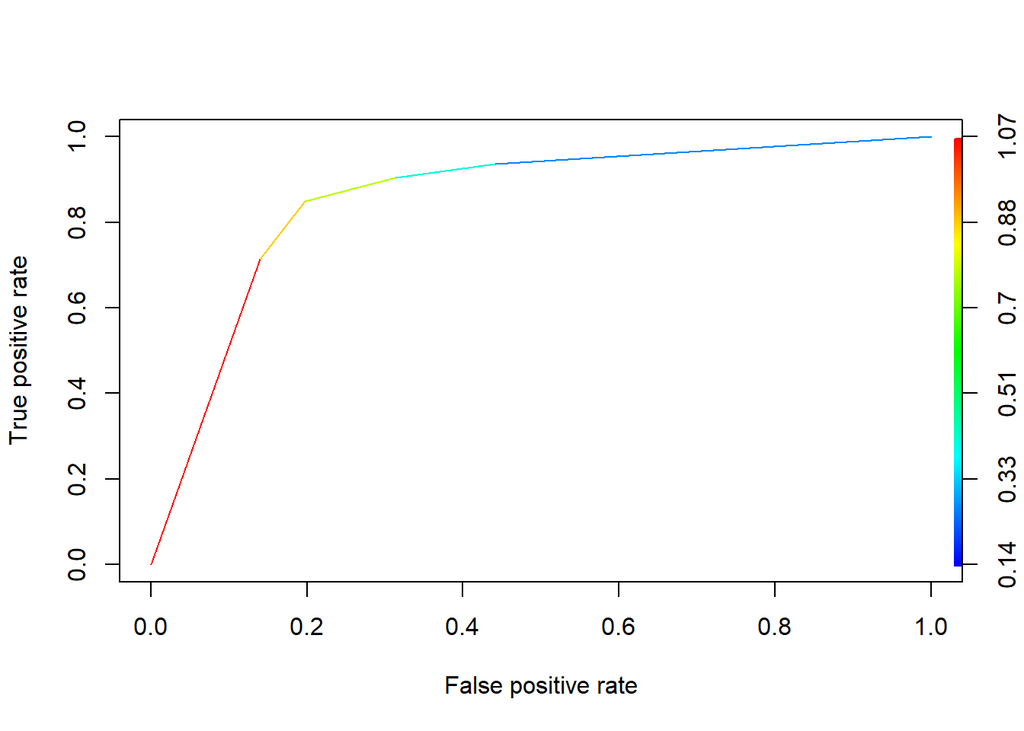

```r
data$heart_disease<-as.factor(data$heart_disease)

#LOSS
LOSS=(insamplecost0<-cost1(data$heart_disease,pred0))
#Misclassification rate
MCR=(insampleMCR0<-mean(data$heart_disease!=pred0))

#Roc curve | AUC
pred0_roc<- predict(hrtDS.rpart0, type="prob")[,2]
pred <- prediction(pred0_roc,data[,14])
perf <- performance(pred, "tpr", "fpr")
plot(perf, colorize=TRUE)
```

```r
#Get the AUC
AUC=unlist(slot(performance(pred, "auc"), "y.values"))

rslt_sym<-c(LOSS,MCR,AUC)
rslt_sym
```

```
## [1] 0.5283019 0.1698113 0.8554356
```

**Asymmetric Evaluation**

Here we try tocalculate the criterians **Missclassification rate | LOSS | AUC** for Asymmetric cost

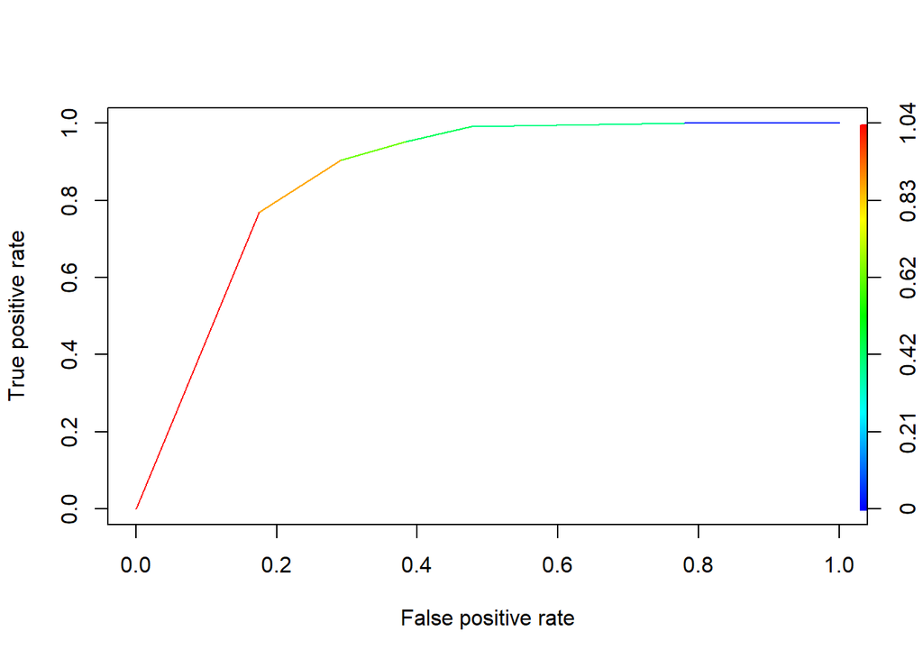

```r
#LOSS
LOSS=(insamplecost.df<-cost1(data$heart_disease,pred1))
#Misclassification rate
MCR=(insampleMCR.df<-mean(data$heart_disease!=pred1))

#roc curve | AUC
pred1_roc<- predict(hrtDS.rpart1, type="prob")[,2]
pred <- prediction(pred1_roc,as.numeric(data$heart_disease))
perf <- performance(pred, "tpr", "fpr")
plot(perf, colorize=TRUE)
```

```r
#Get the AUC
AUC=unlist(slot(performance(pred, "auc"), "y.values"))

rslt_Asym<-c(LOSS,MCR,AUC)
rslt_Asym
```

```
## [1] 0.2169811 0.1981132 0.8633721
```

**Summary table**

```r
eval<-data.frame(rbind(rslt_sym,rslt_Asym),
                 row.names=c('Symmetric cost','Asymmetric cost'))
colnames(eval) <- c("COST", "MCR","AUC")



kable(eval)  %>%
  kable_styling(bootstrap_options = c("striped", "hover", "responsive"),
                font_size = 12, position = "left", full_width = FALSE)
```

|  | COST | MCR | AUC |
| --- | --- | --- | --- |
| Symmetric cost | 0.5283019 | 0.1698113 | 0.8554356 |
| Asymmetric cost | 0.2169811 | 0.1981132 | 0.8633721 |

Conclusion: **ASY wins**

### 7.2.1 Classification Tree

The ideal way of creating a binary tree is to construct a large tree and then prune it to an optimum level

```r
hrtDS.rpart_prune <- rpart(formula = heart_disease ~ . ,
                           data = data, method = "class",
                           parms = list(loss=matrix(c(0,5,1,0), nrow = 2)),
                           cp = 0.001)
```

We have a bushy tree, Now we can try to prune up to a optimum level using plotcp function

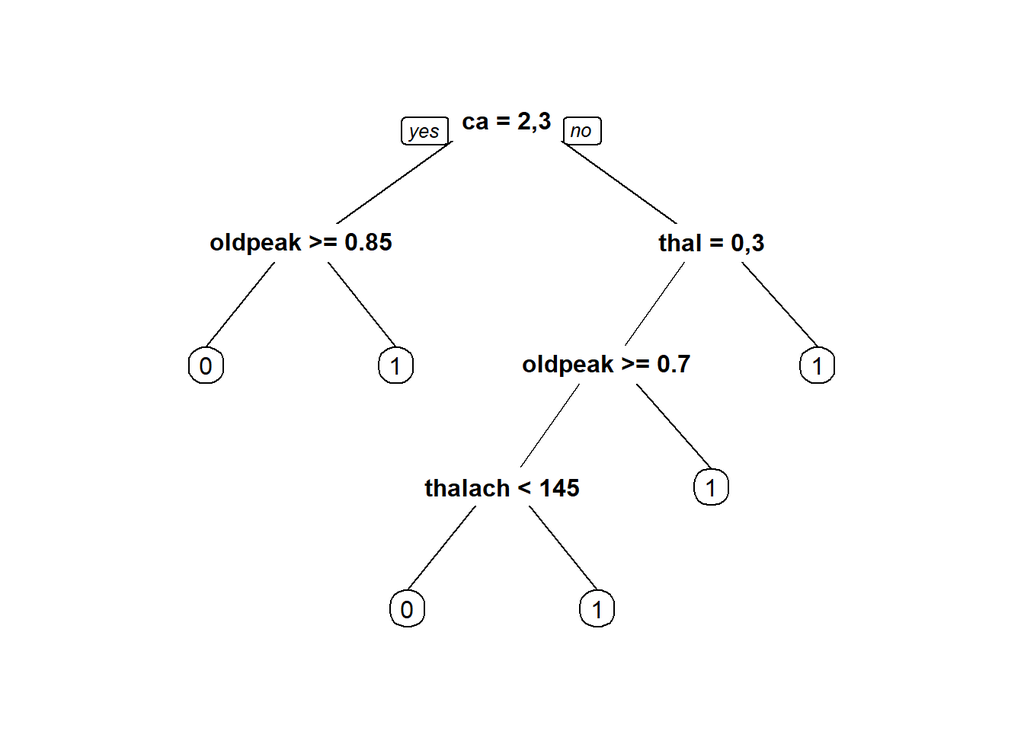

```r
prp(hrtDS.rpart_prune)
```

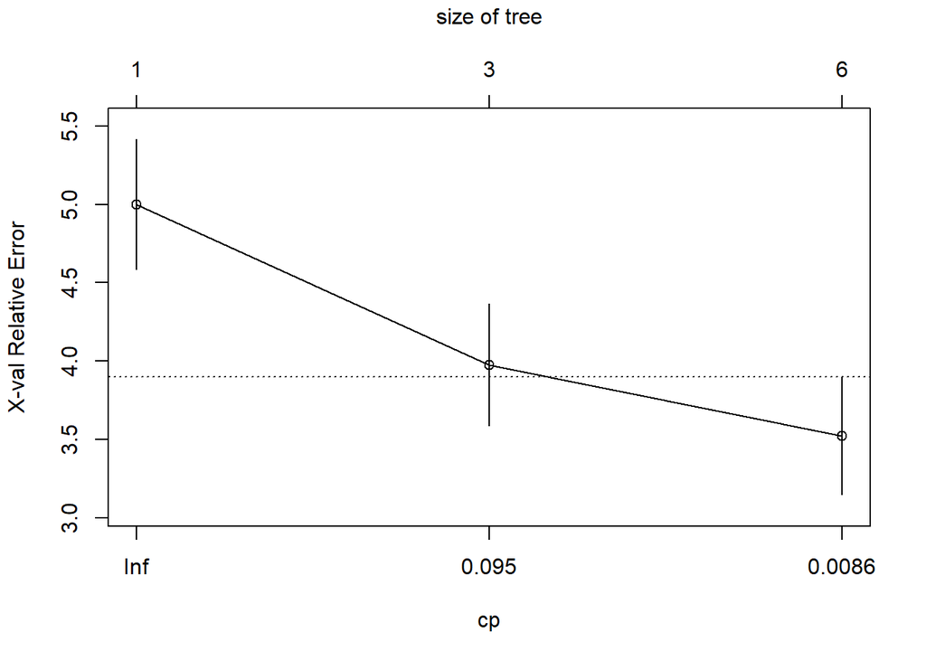

```r
plotcp(hrtDS.rpart_prune)
```

```r
printcp(hrtDS.rpart_prune)
```

```
##
## Classification tree:
## rpart(formula = heart_disease ~ ., data = data, method = "class",
##     parms = list(loss = matrix(c(0, 5, 1, 0), nrow = 2)), cp = 0.001)
##
## Variables actually used in tree construction:
## [1] ca      oldpeak thal    thalach
##
## Root node error: 86/212 = 0.40566
##
## n= 212
##
##         CP nsplit rel error xerror    xstd
## 1 0.122093      0   1.00000 5.0000 0.41566
## 2 0.073643      2   0.75581 3.9767 0.39093
## 3 0.001000      5   0.53488 3.5233 0.37678
```

```r
hrtDS.rpart_prune1<-prune(hrtDS.rpart_prune, cp = 0.0086)
```

### 7.2.2 Model Assessment

**Insample Prediction**

```r
hrtDS.rpart_prune1.pred.in<- predict(hrtDS.rpart_prune1, type="class")
table(data$heart_disease, hrtDS.rpart_prune1.pred.in, dnn=c("Truth","Predicted"))
```

```
##      Predicted
## Truth   0   1
##     0  45  41
##     1   1 125
```

Lets check out the criterians for model evaluation…

**Missclassification rate | LOSS | AUC**

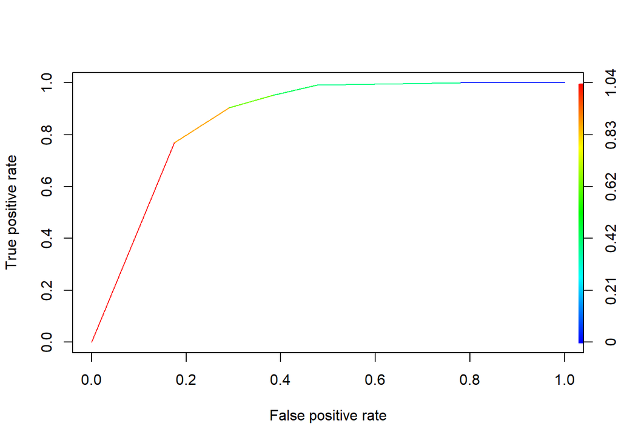

```r
#LOSS
LOSS=(dt.insamplecost<-cost1(data$heart_disease,hrtDS.rpart_prune1.pred.in))
#Misclassification rate
MCR=(dt.insampleMCR<-mean(data$heart_disease!=hrtDS.rpart_prune1.pred.in))
#roc curve | AUC
hrtDS.rpart_prune1.pred.in_roc<- predict(hrtDS.rpart_prune1, type="prob")[,2]
pred <- prediction(hrtDS.rpart_prune1.pred.in_roc,data$heart_disease)
perf <- performance(pred, "tpr", "fpr")
plot(perf, colorize=TRUE)
```

```r
#Get the AUC
AUC=unlist(slot(performance(pred, "auc"), "y.values"))
#vectorized output
dt.rslt.in<-c(LOSS,MCR,AUC)
dt.rslt.in
```

```
## [1] 0.2169811 0.1981132 0.8633721
```

**Out of sample Prediction**

```r
hrtDS.rpart_prune1.pred.out<- predict(hrtDS.rpart_prune1,data_test, type="class")
table(data_test$heart_disease, hrtDS.rpart_prune1.pred.out, dnn=c("Truth","Predicted"))
```

```
##      Predicted
## Truth  0  1
##     0 27 25
##     1  2 37
```

**Missclassification rate | LOSS | AUC**

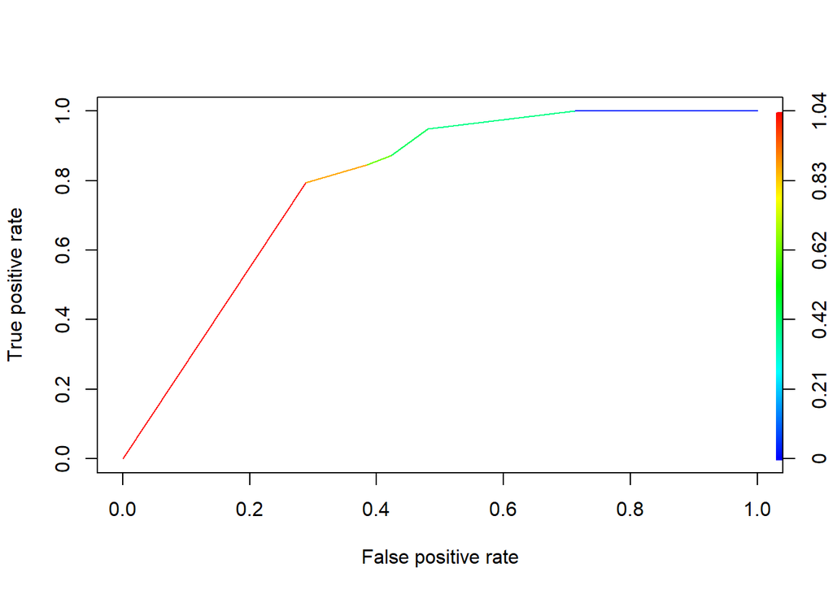

```r
#LOSS
LOSS=(dt.outsamplecost<-cost1(data_test$heart_disease,hrtDS.rpart_prune1.pred.out))
#Misclassification rate
MCR=(dt.outsampleMCR<-mean(data_test$heart_disease!=hrtDS.rpart_prune1.pred.out))

#roc curve | AUC
hrtDS.rpart_prune1.pred.out_roc<- predict(hrtDS.rpart_prune1,data_test, type="prob")[,2]
pred <- prediction(hrtDS.rpart_prune1.pred.out_roc,as.numeric(data_test$heart_disease))
perf.dt1 <- performance(pred, "tpr", "fpr")
plot(perf.dt1, colorize=TRUE)
```

```r
#Get the AUC
AUC=unlist(slot(performance(pred, "auc"), "y.values"))
#vectorized output
dt.rslt.out<-c(LOSS,MCR,AUC)
dt.rslt.out
```

```
## [1] 0.3846154 0.2967033 0.7924063
```

```r
eval<-data.frame(rbind(dt.rslt.in,dt.rslt.out),
                 row.names=c('DT: in','DT: out'))
colnames(eval) <- c("COST", "MCR","AUC")

kable(eval)  %>%
  kable_styling(bootstrap_options = c("striped", "hover", "responsive"),
                font_size = 12, position = "left", full_width = FALSE)
```

|  | COST | MCR | AUC |
| --- | --- | --- | --- |
| DT: in | 0.2169811 | 0.1981132 | 0.8633721 |
| DT: out | 0.3846154 | 0.2967033 | 0.7924063 |

### 7.3 GAM:

#### 7.3.1 Modelling

```r
#fetch numeric columns
numcols<-select_if(data_orig, is.numeric)
#fetch character columns
charcols<-select_if(data_orig, is.factor)

#continious columns names
(n<-colnames(numcols)[1:5])
```

```
## [1] "age"      "trestbps" "chol"     "thalach"  "oldpeak"
```

```r
#character columns names
colnames(charcols)
```

```
## [1] "sex"     "cp"      "fbs"     "restecg" "exang"   "slope"   "ca"
## [8] "thal"
```

```r
#continious columns names
cont<-colnames(numcols)
#character columns names
n <- names(data)

formula.gam <- as.formula(paste("heart_disease ~s(age)+s(trestbps)+s(chol) +s(thalach) +s(oldpeak) +",
                      paste(n[!n %in% cont], collapse = " + ")))
formula.gam
```

```
## heart_disease ~ s(age) + s(trestbps) + s(chol) + s(thalach) +
##     s(oldpeak) + sex + cp + fbs + restecg + exang + slope + ca +
##     thal
```

```r
hrtDS.gam <- gam(formula = formula.gam, family=binomial,data=data);
summary(hrtDS.gam)
```

```
##
## Family: binomial
## Link function: logit
##
## Formula:
## heart_disease ~ s(age) + s(trestbps) + s(chol) + s(thalach) +
##     s(oldpeak) + sex + cp + fbs + restecg + exang + slope + ca +
##     thal
##
## Parametric coefficients:
##                      Estimate Std. Error z value Pr(>|z|)
## (Intercept)        -2.959e+00  2.835e+00  -1.044  0.29663
## sexmale            -2.353e+00  9.793e-01  -2.403  0.01625 *
## cpatypical angina   2.483e-01  8.929e-01   0.278  0.78097
## cpnon-anginal pain  1.186e+00  7.301e-01   1.625  0.10424
## fbs>120             1.446e+00  9.946e-01   1.454  0.14593
## restecgdefinite    -5.351e+01  4.745e+07   0.000  1.00000
## restecgnormal      -7.645e-01  5.813e-01  -1.315  0.18847
## exangyes           -7.125e-01  6.413e-01  -1.111  0.26659
## slope1              7.726e-01  1.584e+00   0.488  0.62571
## slope2              1.478e+00  1.751e+00   0.844  0.39878
## ca1                -2.131e+00  7.968e-01  -2.674  0.00750 **
## ca2                -4.755e+00  1.194e+00  -3.982 6.84e-05 ***
## ca3                -4.941e+00  1.707e+00  -2.894  0.00380 **
## ca4                 4.847e+01  3.875e+07   0.000  1.00000
## thal1               7.125e+00  2.618e+00   2.722  0.00649 **
## thal2               7.174e+00  2.377e+00   3.018  0.00254 **
## thal3               4.523e+00  2.237e+00   2.021  0.04323 *
## ---
## Signif. codes:  0 '***' 0.001 '**' 0.01 '*' 0.05 '.' 0.1 ' ' 1
##
## Approximate significance of smooth terms:
##               edf Ref.df Chi.sq p-value
## s(age)      8.226  8.583 15.469  0.0680 .
## s(trestbps) 1.000  1.000  3.236  0.0721 .
## s(chol)     2.627  3.329  8.159  0.0627 .
## s(thalach)  3.176  3.983  5.228  0.2498
## s(oldpeak)  5.268  6.271 11.667  0.0778 .
## ---
## Signif. codes:  0 '***' 0.001 '**' 0.01 '*' 0.05 '.' 0.1 ' ' 1
##
## R-sq.(adj) =  0.646   Deviance explained = 66.2%
## UBRE = -0.19181  Scale est. = 1         n = 212
```

[figure not shown]

```r
plot(hrtDS.gam, shade=TRUE,seWithMean=TRUE,scale=0, pages = 1)
```

```r
AIC(hrtDS.gam)
```

```
## [1] 171.3359
```

```r
BIC(hrtDS.gam)
```

```
## [1] 296.5283
```

```r
hrtDS.gam$deviance
```

```
## [1] 96.74079
```

#### 7.3.2 Model Assessment

**Insample Performance**

```r
pcut.gam <- .20
prob.gam.in<-predict(hrtDS.gam,type="response")
pred.gam.in.class<-(prob.gam.in>=pcut.gam)*1
table(data$heart_disease,pred.gam.in.class,dnn=c("Observed","Predicted"))
```

```
##         Predicted
## Observed   0   1
##        0  60  26
##        1   2 124
```

Lets check out the criterians for model evaluation…

**Missclassification rate | LOSS | AUC**

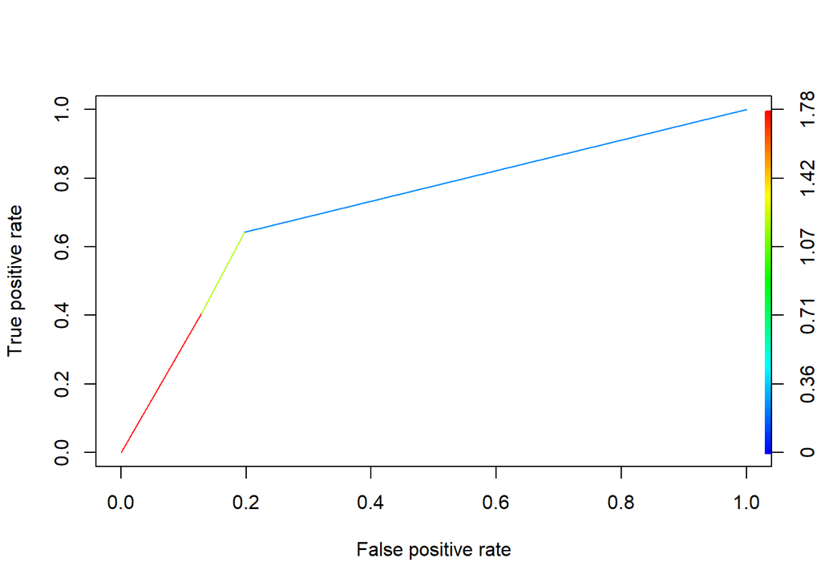

```r
#LOSS
LOSS=(gam.insamplecost<-cost1(data$heart_disease,pred.gam.in.class))
#Misclassification rate
MCR=(dt.insampleMCR<-mean(data$heart_disease!=pred.gam.in.class))

#roc curve | AUC
pred.gam.class.in_roc<- predict(hrtDS.gam, type="prob")[,2]
pred <- prediction(as.numeric(pred.gam.class.in_roc),as.numeric(data$heart_disease))
perf <- performance(pred, "tpr", "fpr")
plot(perf, colorize=TRUE)
```

```r
#Get the AUC
AUC=unlist(slot(performance(pred, "auc"), "y.values"))
#vectorized output
gam.rslt.in<-c(LOSS,MCR,AUC)
gam.rslt.in
```

```
## [1] 0.1698113 0.1320755 0.7214839
```

**Out of sample Prediction**

```r
prob.gam.out<-predict(hrtDS.gam,data_test,type="response")
pred.gam.out.class<-(prob.gam.out>=pcut.gam)*1
table(data_test$heart_disease,pred.gam.out.class,dnn=c("Observed","Predicted"))
```

```
##         Predicted
## Observed  0  1
##        0 22 30
##        1  2 37
```

**Missclassification rate | LOSS | AUC**

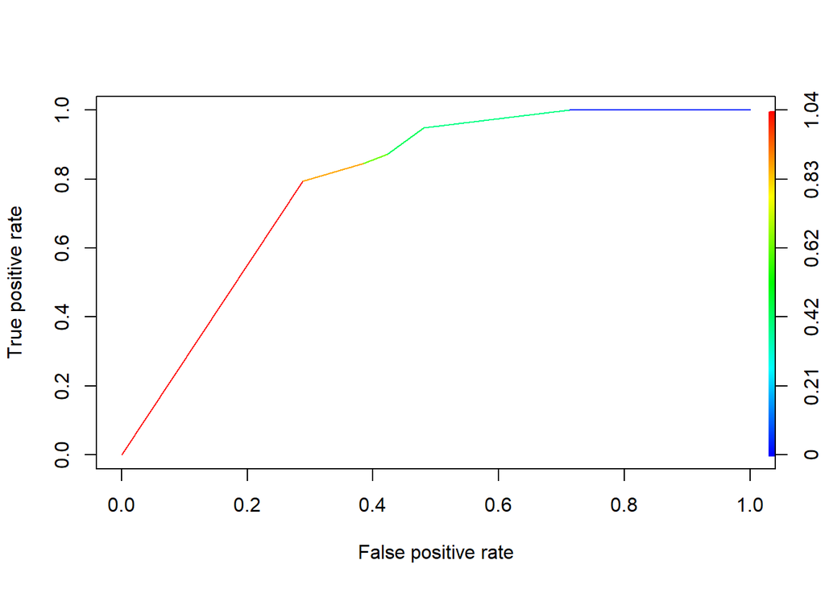

```r
#LOSS
LOSS=(dt.outsamplecost<-cost1(data_test$heart_disease,pred.gam.out.class))
#Misclassification rate
MCR=(dt.outsampleMCR<-mean(data_test$heart_disease!=pred.gam.out.class))

#roc curve | AUC
hrtDS.gam.out_roc<- predict(hrtDS.rpart_prune1,data_test, type="prob")[,2]
pred <- prediction(as.numeric(hrtDS.gam.out_roc),as.numeric(data_test$heart_disease))
perf.gm <- performance(pred, "tpr", "fpr")
plot(perf.gm, colorize=TRUE)
```

```r
#Get the AUC
AUC=unlist(slot(performance(pred, "auc"), "y.values"))
#vectorized output
gam.rslt.out<-c(LOSS,MCR,AUC)
gam.rslt.out
```

```
## [1] 0.4395604 0.3516484 0.7924063
```

```r
eval<-data.frame(rbind(gam.rslt.in,gam.rslt.out),
                 row.names=c('GAM: in','GAM: out'))
colnames(eval) <- c("COST", "MCR","AUC")

kable(eval)  %>%
  kable_styling(bootstrap_options = c("striped", "hover", "responsive"),
                font_size = 12, position = "left", full_width = FALSE)
```

|  | COST | MCR | AUC |
| --- | --- | --- | --- |
| GAM: in | 0.1698113 | 0.1320755 | 0.7214839 |
| GAM: out | 0.4395604 | 0.3516484 | 0.7924063 |

### 7.4 Ensemble Methods

Advanced Tree Models Bagging, Random Forests, and Boosting

#### 7.4.1 Bagging

Bagging stands for Bootstrap and Aggregating. It employs the idea of bootstrap but the purpose is not to study bias and standard errors of estimates. Instead, the goal of Bagging is to improve prediction accuracy. It fits a tree for each bootsrap sample, and then aggregate the predicted values from all these different trees. For more details, you may look at Wikepedia, or you can find the original paper Leo Breiman (1996).

**To my best knowledge, it seems that bagging() won’t take an argument for asymmetric loss. Therefore, the classification results might not be appropriate.Lets check it out…**

**Modelling**

```r
heart.bag<- randomForest(as.factor(heart_disease)~.,mtry=ncol(data)-1, data = data, nbagg=100)
```

**Insample**

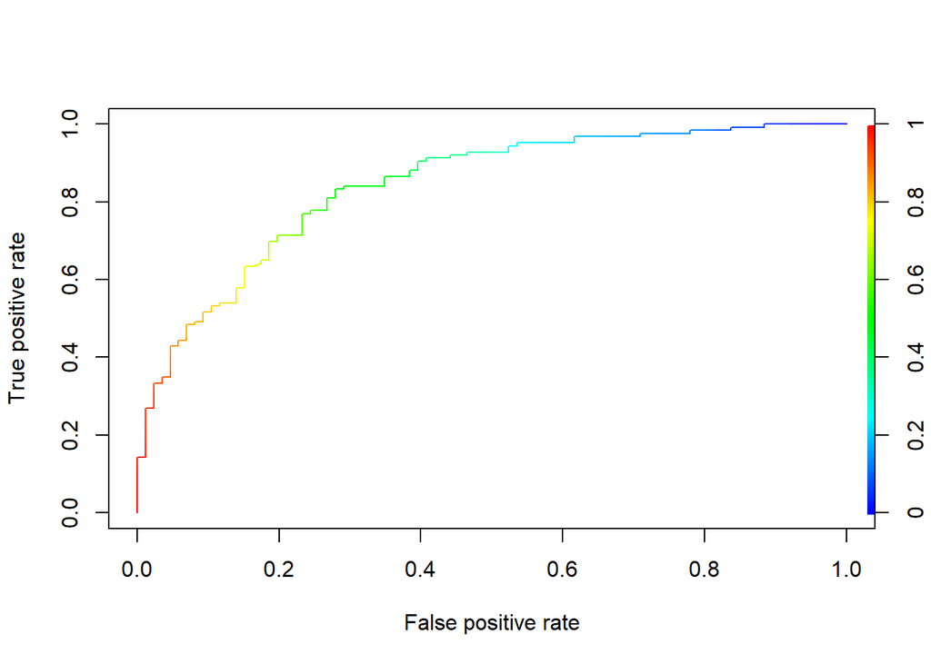

```r
heart.bag.pred<- predict(heart.bag, type="prob")[,2]
pred.bag = prediction(heart.bag.pred, data$heart_disease)
perf = performance(pred.bag, "tpr", "fpr")
plot(perf, colorize=TRUE)
```

```r
unlist(slot(performance(pred.bag, "auc"), "y.values"))
```

```
## [1] 0.84067
```

**Insample Analysis**

```r
heart.bag.pred<- predict(heart.bag, newdata = data, type="class")
table(data$heart_disease, heart.bag.pred, dnn = c("True", "Pred"))
```

```
##     Pred
## True   0   1
##    0  86   0
##    1   0 126
```

```r
#LOSS
LOSS<-cost0(data$heart_disease,heart.bag.pred)
#Misclassification rate
MCR<-mean(data$heart_disease!=heart.bag.pred)
#Get the AUC
AUC=unlist(slot(performance(pred.bag, "auc"), "y.values"))

rslt.bag.in<-c(LOSS,MCR,AUC)
rslt.bag.in
```

```
## [1] 0.00000 0.00000 0.84067
```

**Out of sample**

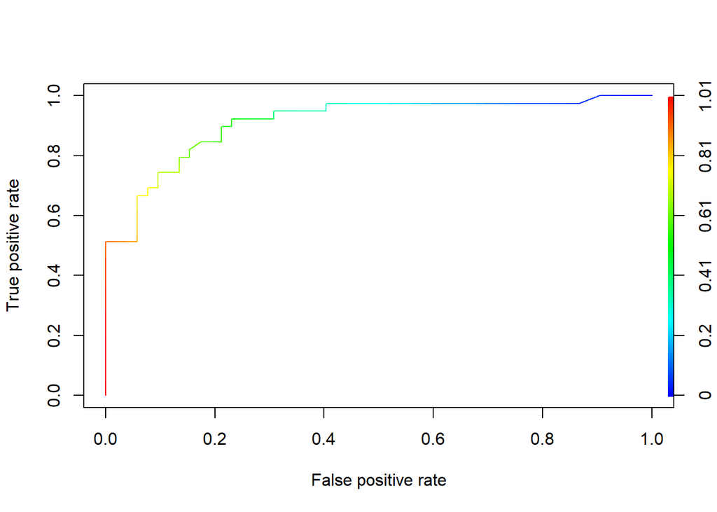

```r
levels(data_test$thal) <- levels(data$thal)
levels(data_test$ca) <- levels(data$ca)
levels(data_test$slope) <- levels(data$slope)
levels(data_test$exang) <- levels(data$exang)
levels(data_test$restecg) <- levels(data$restecg)
levels(data_test$fbs) <- levels(data$fbs)
levels(data_test$cp) <- levels(data$cp)
levels(data_test$sex) <- levels(data$sex)

data_test$heart_disease <-as.factor(data_test$heart_disease)
heart.bag.pred.test<- predict(heart.bag, newdata = data_test, type="prob")[,2]
pred.bag.out = prediction(heart.bag.pred.test, data_test$heart_disease)
perf.bg = performance(pred.bag.out, "tpr", "fpr")
plot(perf.bg, colorize=TRUE)
```

```r
unlist(slot(performance(pred.bag.out, "auc"), "y.values"))
```

```
## [1] 0.9114892
```

```r
heart.bag.pred.test<- predict(heart.bag, newdata = data_test, type="class")
table(data_test$heart_disease, heart.bag.pred.test, dnn = c("True", "Pred"))
```

```
##     Pred
## True  0  1
##    0 40 12
##    1  3 36
```

```r
#LOSS
LOSS<-cost0(data_test$heart_disease,heart.bag.pred.test)
#Misclassification rate
MCR<-mean(data_test$heart_disease!=heart.bag.pred.test)
#Get the AUC
AUC=unlist(slot(performance(pred.bag.out, "auc"), "y.values"))

rslt.bag.out<-c(LOSS,MCR,AUC)
rslt.bag.out
```

```
## [1] 0.1648352 0.1648352 0.9114892
```

```r
eval<-data.frame(rbind(rslt.bag.in,rslt.bag.out),
                 row.names=c('BAG: in','BAG: out'))
colnames(eval) <- c("COST", "MCR","AUC")

kable(eval)  %>%
  kable_styling(bootstrap_options = c("striped", "hover", "responsive"),
                font_size = 12, position = "left", full_width = FALSE)
```

|  | COST | MCR | AUC |
| --- | --- | --- | --- |
| BAG: in | 0.0000000 | 0.0000000 | 0.8406700 |
| BAG: out | 0.1648352 | 0.1648352 | 0.9114892 |

#### 7.4.1 Random Forest

**Modelling**

```r
heart.rf<- randomForest(as.factor(heart_disease)~., mtry=sqrt(ncol(data)-1),ntree=100 ,data = data, importance=TRUE)
heart.rf
```

```
##
## Call:
##  randomForest(formula = as.factor(heart_disease) ~ ., data = data,      mtry = sqrt(ncol(data) - 1), ntree = 100, importance = TRUE)
##                Type of random forest: classification
##                      Number of trees: 100
## No. of variables tried at each split: 4
##
##         OOB estimate of  error rate: 18.87%
## Confusion matrix:
##    0   1 class.error
## 0 61  25   0.2906977
## 1 15 111   0.1190476
```

**Variable Importance**

```r
heart.rf$importance
```

```
##                      0             1 MeanDecreaseAccuracy MeanDecreaseGini
## age       0.0066894627  0.0090019272         0.0080007447        9.7652322
## sex       0.0100411368  0.0089640079         0.0093973826        2.4283983
## cp        0.0236545789  0.0049268001         0.0124314370        7.5084754
## trestbps  0.0008585000  0.0010609511         0.0008679932        7.5703744
## chol      0.0079340813  0.0083961522         0.0081707502       10.6459891
## fbs      -0.0004175059 -0.0017677013        -0.0011811390        0.8207861
## restecg  -0.0027415097  0.0006863955        -0.0007813800        1.6776843
## thalach   0.0066289697  0.0025489093         0.0038556271       10.9100373
## exang     0.0028168382  0.0026346946         0.0029136281        2.5030901
## oldpeak   0.0314505792  0.0065132308         0.0166571509       14.2058831
## slope     0.0135692685 -0.0011422479         0.0052397966        4.3544639
## ca        0.0554900045  0.0328762794         0.0416077239       12.8668417
## thal      0.0586233858  0.0391646094         0.0464907871       16.0030334
```

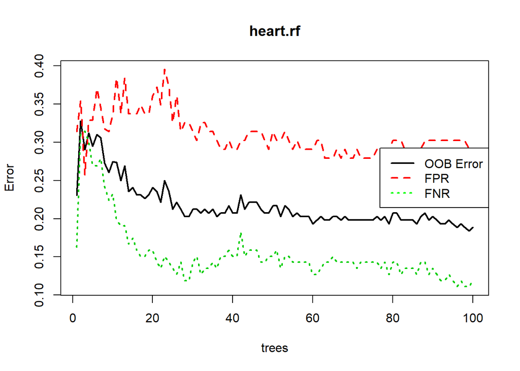

```r
plot(heart.rf, lwd=rep(2, 3))
legend("right", legend = c("OOB Error", "FPR", "FNR"), lwd=rep(2, 3), lty = c(1,2,3), col = c("black", "red", "green"))
```

**Optimal cutoff - Symmetric cost**

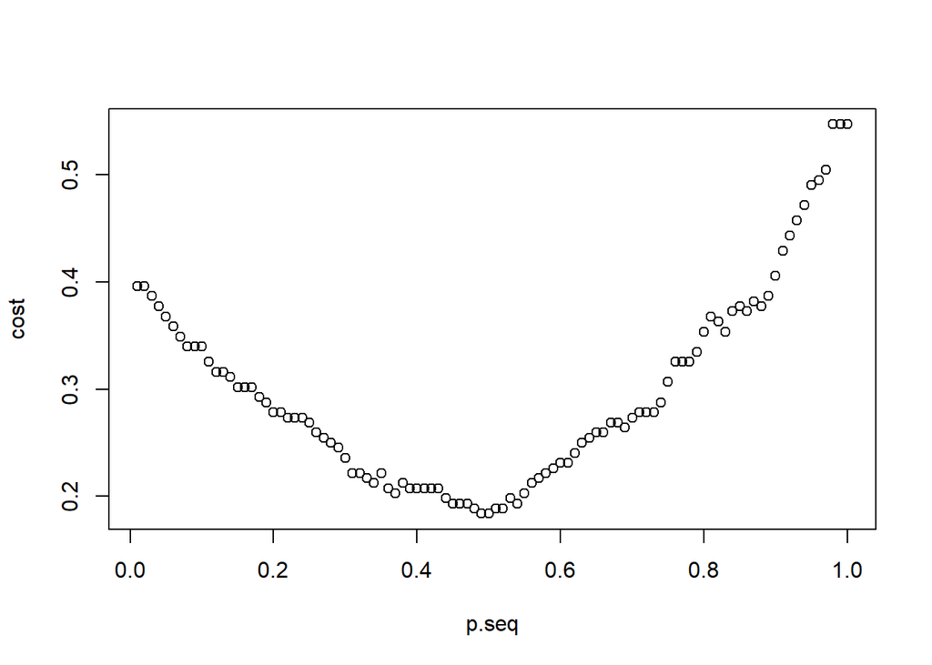

```r
heart.rf.pred<- predict(heart.rf, type = "prob")[,2]

p.seq = seq(0.01, 1, 0.01)
cost = rep(0, length(p.seq))
for(i in 1:length(p.seq)){
    cost[i] = costfunc(obs = data$heart_disease, pred.p = heart.rf.pred, pcut = p.seq[i])
}
plot(p.seq, cost)
```

```r
optimal.pcut.sym= p.seq[which(cost==min(cost))][1]

optimal.pcut.sym#0.62
```

```
## [1] 0.49
```

**Insample Analysis**

**ROC CURVE**

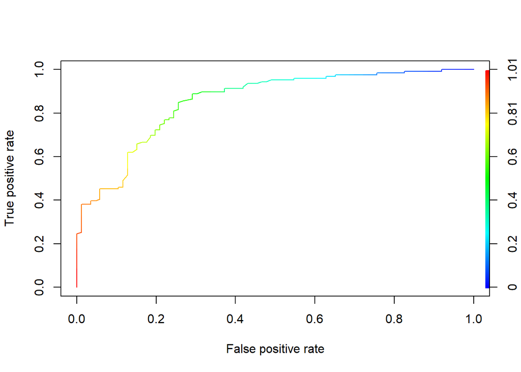

```r
pred.rf.in <- prediction(heart.rf.pred, data$heart_disease)
perf <- performance(pred.rf.in, "tpr", "fpr")
plot(perf, colorize=TRUE)
```

```r
unlist(slot(performance(pred.rf.in, "auc"), "y.values"))
```

```
## [1] 0.8551587
```

```r
heart.rf.pred.c<- predict(heart.bag, newdata = data, type="class")
table(data$heart_disease, heart.rf.pred.c, dnn = c("True", "Pred"))
```

```
##     Pred
## True   0   1
##    0  86   0
##    1   0 126
```

**Out-of-Sample - Symmetric**

```r
## out-of-sample
heart.rf.pred.test<- predict(heart.rf,newdata = data_test,type="prob")[,2]
heart.rf.class.test<- (heart.rf.pred.test>optimal.pcut.sym)*1
table(data_test$heart_disease, heart.rf.class.test, dnn = c("True", "Pred"))
```

```
##     Pred
## True  0  1
##    0 42 10
##    1  5 34
```

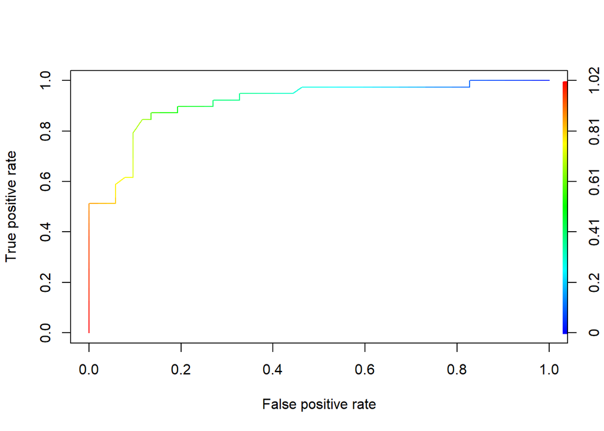

```r
pred.rf.out <- prediction(heart.rf.pred.test, data_test$heart_disease)
perf <- performance(pred.rf.out, "tpr", "fpr")
plot(perf, colorize=TRUE)
```

```r
unlist(slot(performance(pred.rf.out, "auc"), "y.values"))
```

```
## [1] 0.9146943
```

```r
#LOSS
LOSS<-cost0(data_test$heart_disease,heart.rf.class.test)
#Misclassification rate
MCR<-mean(data_test$heart_disease!=heart.rf.class.test)
#Get the AUC
AUC=unlist(slot(performance(pred.rf.out, "auc"), "y.values"))

rslt.rf.out.sym<-c(LOSS,MCR,AUC)
rslt.rf.out.sym
```

```
## [1] 0.1648352 0.1648352 0.9146943
```

**Optimal cutoff - Assymetric cost**

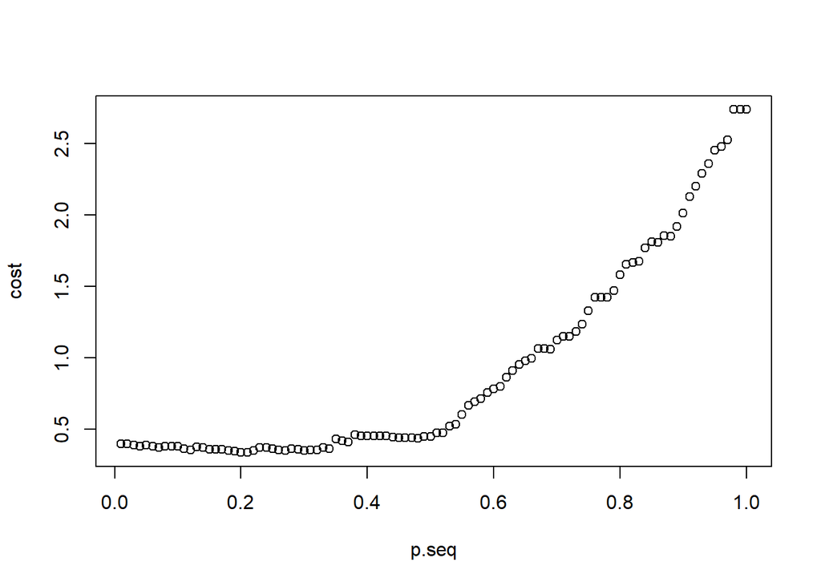

```r
p.seq = seq(0.01, 1, 0.01)
cost = rep(0, length(p.seq))
for(i in 1:length(p.seq)){
    cost[i] = costfuncasym(obs = data$heart_disease, pred.p = heart.rf.pred, pcut = p.seq[i])
}
plot(p.seq, cost)
```

```r
optimal.pcut.asym= p.seq[which(cost==min(cost))][1]

optimal.pcut.asym#0.07
```

```
## [1] 0.2
```

**Out-of-Sample Asymmetric**

```r
## out-of-sample
heart.rf.pred.test<- predict(heart.rf,newdata = data_test,type="prob")[,2]
heart.rf.class.test<- (heart.rf.pred.test>optimal.pcut.asym)*1
table(data_test$heart_disease, heart.rf.class.test, dnn = c("True", "Pred"))
```

```
##     Pred
## True  0  1
##    0 19 33
##    1  1 38
```

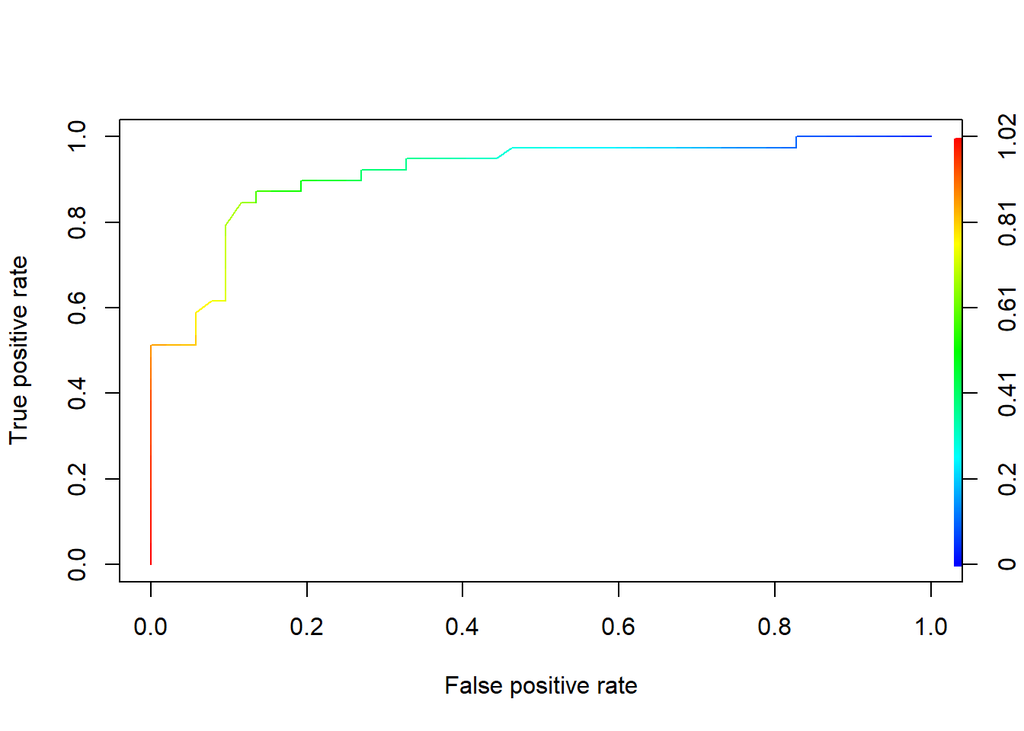

```r
pred.rf.out <- prediction(heart.rf.pred.test, data_test$heart_disease)
perf.rf <- performance(pred.rf.out, "tpr", "fpr")
plot(perf.rf, colorize=TRUE)
```

```r
unlist(slot(performance(pred.rf.out, "auc"), "y.values"))
```

```
## [1] 0.9146943
```

```r
#LOSS
LOSS<-cost1(data_test$heart_disease,heart.rf.class.test)
#Misclassification rate
MCR<-mean(data_test$heart_disease!=heart.rf.class.test)
#Get the AUC
AUC=unlist(slot(performance(pred.rf.out, "auc"), "y.values"))

rslt.rf.out.asym<-c(LOSS,MCR,AUC)
rslt.rf.out.asym
```

```
## [1] 0.4175824 0.3736264 0.9146943
```

```r
eval<-data.frame(rbind(rslt.rf.out.sym,rslt.rf.out.asym),
                 row.names=c('Random Forest: Symmetric : Out_sample',
                             'Random Forest: Asymmetric : Out_sample'))
colnames(eval) <- c("COST", "MCR","AUC")

kable(eval)  %>%
  kable_styling(bootstrap_options = c("striped", "hover", "responsive"),
                font_size = 12, position = "left", full_width = FALSE)
```

|  | COST | MCR | AUC |
| --- | --- | --- | --- |
| Random Forest: Symmetric : Out_sample | 0.1648352 | 0.1648352 | 0.9146943 |
| Random Forest: Asymmetric : Out_sample | 0.4175824 | 0.3736264 | 0.9146943 |

#### 7.4.2 Boosting

```r
data$heart_disease= as.factor(data$heart_disease)

heart.boost= boosting(heart_disease~., data = data, boos = T)
```

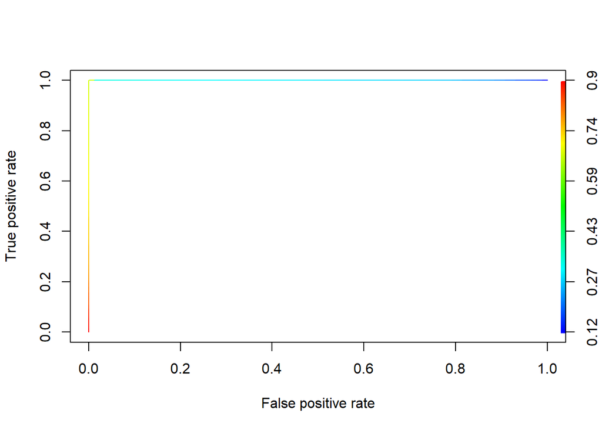

```r
# Training AUC
pred.heart.boost= predict(heart.boost, newdata = data)
pred <- prediction(pred.heart.boost$prob[,2], data$heart_disease)
perf <- performance(pred, "tpr", "fpr")
plot(perf, colorize=TRUE)
```

```r
unlist(slot(performance(pred, "auc"), "y.values"))
```

```
## [1] 1
```

**Boosting in sample**

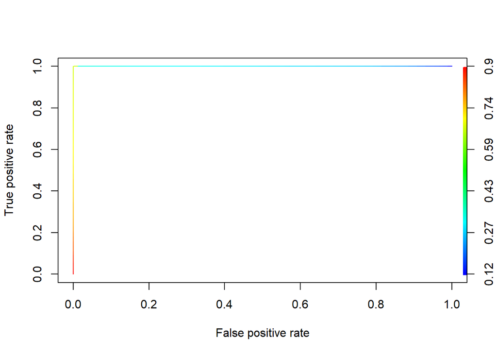

```r
pred.heart.boost.train= predict(heart.boost, newdata = data)
#LOSS
LOSS<-cost0(data$heart_disease,as.numeric(pred.heart.boost.train$class))
#Misclassification rate
MCR<-mean(data$heart_disease!=as.numeric(pred.heart.boost.train$class))


# Testing AUC
pred <- prediction(pred.heart.boost.train$prob[,2], data$heart_disease)
perf <- performance(pred, "tpr", "fpr")
plot(perf, colorize=TRUE)
```

```r
#Get the AUC
AUC=unlist(slot(performance(pred, "auc"), "y.values"))

boost_in<-c(LOSS,MCR,AUC)
boost_in
```

```
## [1] 0 0 1
```

**Boosting out sample**

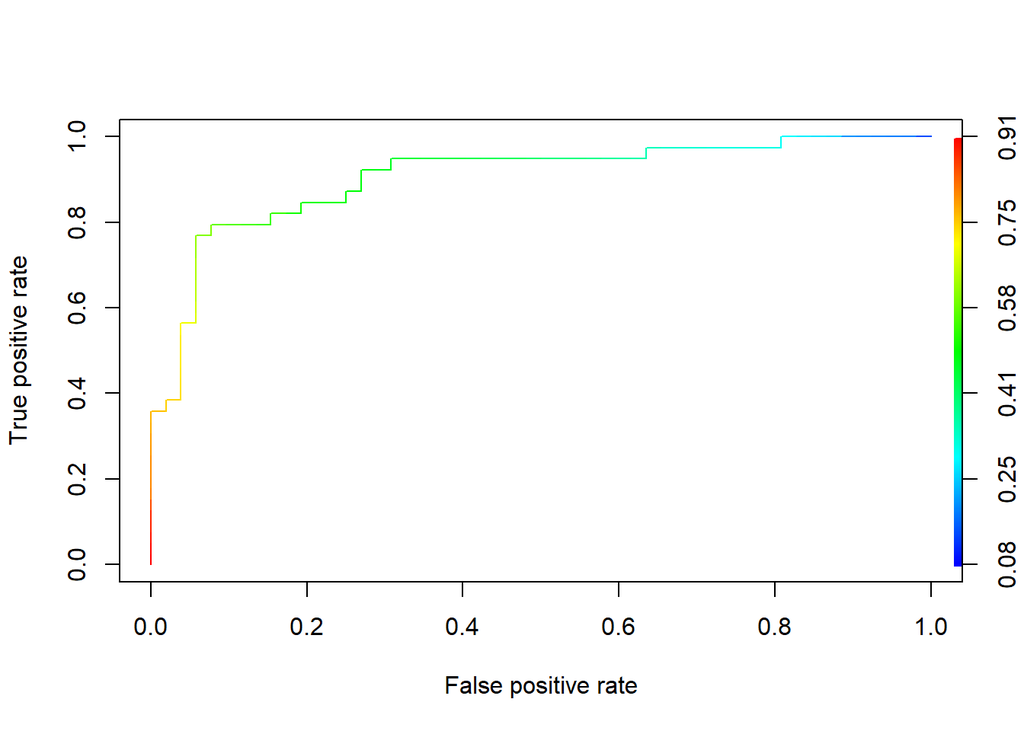

```r
pred.heart.boost.test= predict(heart.boost, newdata = data_test)
#LOSS
LOSS<-cost0(data_test$heart_disease,as.numeric(pred.heart.boost.test$class))
#Misclassification rate
MCR<-mean(data_test$heart_disease!=as.numeric(pred.heart.boost.test$class))


# Testing AUC
pred <- prediction(pred.heart.boost.test$prob[,2], data_test$heart_disease)
perf.bo <- performance(pred, "tpr", "fpr")
plot(perf.bo, colorize=TRUE)
```

```r
#Get the AUC
AUC=unlist(slot(performance(pred, "auc"), "y.values"))

boost_out<-c(LOSS,MCR,AUC)
boost_out
```

```
## [1] 0.1868132 0.1868132 0.9048323
```

```r
eval<-data.frame(rbind(boost_in,boost_out),
                 row.names=c('Boosting: In_sample',
                             'Boosting: Out_sample'))
colnames(eval) <- c("COST", "MCR","AUC")

kable(eval)  %>%
  kable_styling(bootstrap_options = c("striped", "hover", "responsive"),
                font_size = 12, position = "left", full_width = FALSE)
```

|  | COST | MCR | AUC |
| --- | --- | --- | --- |
| Boosting: In_sample | 0.0000000 | 0.0000000 | 1.0000000 |
| Boosting: Out_sample | 0.1868132 | 0.1868132 | 0.9048323 |

We ran a neural network model using “heart disease” as the output variable, and the remaining 13 variables as input variables. We trained the model using NeuralNetTools package, in which the size of the hidden layers are calculated internally.For classification problems with nnet you need to code the response to factor first

```r
library(e1071)
library(nnet)
library(NeuralNetTools)
data_orig$heart_disease <- as.factor(data_orig$heart_disease)
```

Sampling Data into 70% and 30% Test

```r
set.seed(13263635)
index <- sample(nrow(data_orig),nrow(data_orig)*0.7)
hd_train <- data_orig[index,]
hd_test <- data_orig[-index,]
```

Evaluating the results:

```r
print(hd.nnet)
```

```
## Neural Network
##
## 212 samples
##  13 predictor
##   2 classes: '0', '1'
##
## No pre-processing
## Resampling: Bootstrapped (25 reps)
## Summary of sample sizes: 212, 212, 212, 212, 212, 212, ...
## Resampling results across tuning parameters:
##
##   size  decay  Accuracy   Kappa
##   1     0e+00  0.6401923  0.09431636
##   1     1e-04  0.6110185  0.00000000
##   1     1e-01  0.7589285  0.48341994
##   3     0e+00  0.6201874  0.05705648
##   3     1e-04  0.6376189  0.13904563
##   3     1e-01  0.7721512  0.51435973
##   5     0e+00  0.6282547  0.09356149
##   5     1e-04  0.6572260  0.17507520
##   5     1e-01  0.7809113  0.53395146
##
## Accuracy was used to select the optimal model using the largest value.
## The final values used for the model were size = 5 and decay = 0.1.
```

```r
plot(hd.nnet)
```

[output not shown]

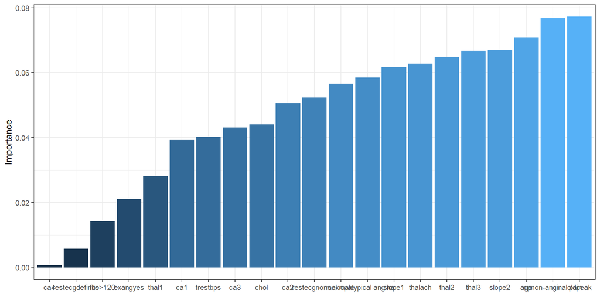

```r
PNN<-plot(garson(hd.nnet))
```

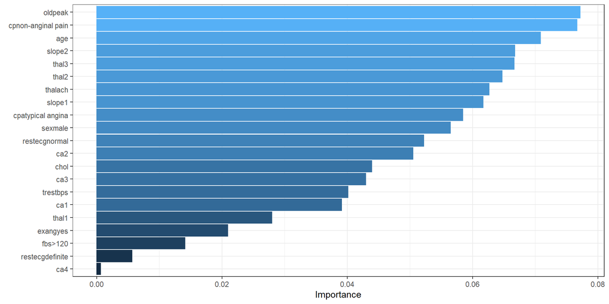

```r
PNN+coord_flip()
```

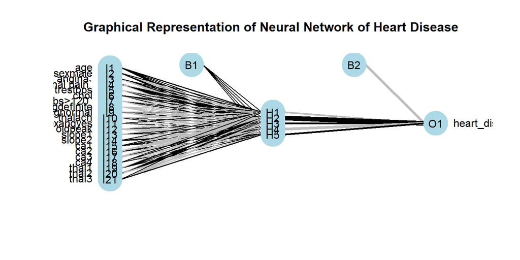

```
## integer(0)
```

```r
plotnet(hd.nnet$finalModel, y_names = "heart_disease") + title("Graphical Representation of Neural Network of Heart Disease ")
```

```r
pred.glm.gtrain.nn <- predict(hd.nnet, type = "prob")[,2]
pred.glm.gtest.nn <- predict(hd.nnet, newdata=hd_test,type = "prob")[,2]
```

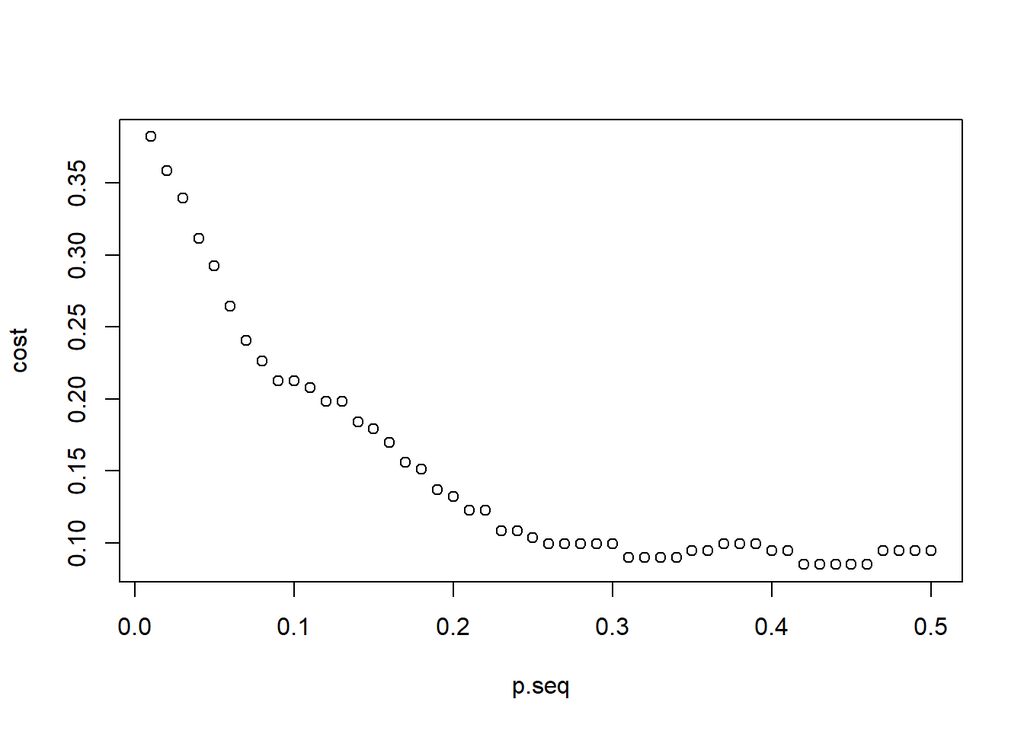

```r
cost_sym <- function(obs, pred.p, pcut){
  weight1 = 1
  weight0 = 1
  c1 = (obs==1)&(pred.p<pcut)
  c0 = (obs==0)&(pred.p>=pcut)
  cost = (mean(weight1*c1+weight0*c0))
  return(cost)
}
# define a sequence from 0.01 to 1 by 0.01
p.seq = seq(0.01, 0.5, 0.01)

# write a loop for all p-cut to see which one provides the smallest cost
# first, need to define a 0 vector in order to save the value of cost from all pcut

cost = rep(0, length(p.seq))
for(i in 1:length(p.seq)){
    cost[i] = cost_sym(obs = hd_train$heart_disease, pred.p = pred.glm.gtrain.nn, pcut = p.seq[i])
}

#optimal pcut to be used further
plot(p.seq, cost)
```

```r
optimal.pcut.sym = p.seq[which(cost == min(cost))]
optimal.pcut.sym #0.5
```

```
## [1] 0.42 0.43 0.44 0.45 0.46
```

Asymmetric : To find Optimal Pcut

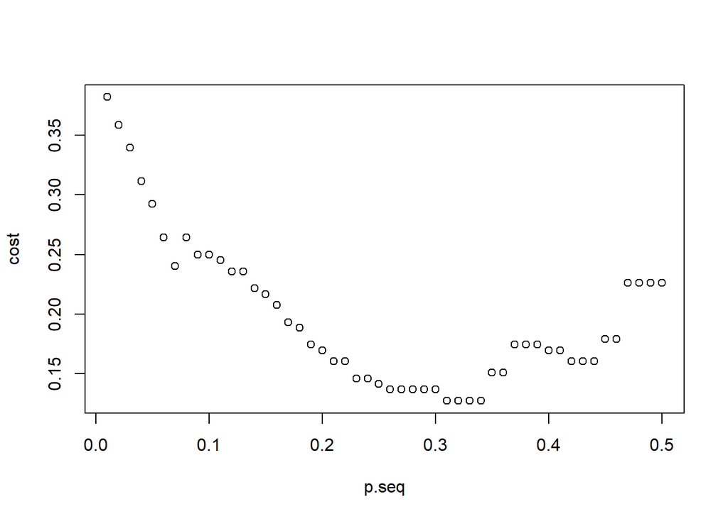

```r
#Cost Function
# define a cost function with input "obs" being observed response
# and "pi" being predicted probability, and "pcut" being the threshold.
cost_asym <- function(obs, pred.p, pcut){
  weight1 = 5
  weight0 = 1
  c1 = (obs==1)&(pred.p<pcut)  # count for "true=1 but pred=0"   (FN)
  c0 = (obs==0)&(pred.p>=pcut) # count for "true=0 but pred=1"   (FP)
  cost = (mean(weight1*c1+weight0*c0)) # misclassification with weight
  return(cost)
}
# define a sequence from 0.01 to 1 by 0.01
p.seq = seq(0.01, 0.5, 0.01)

# write a loop for all p-cut to see which one provides the smallest cost
# first, need to define a 0 vector in order to save the value of cost from all pcut
cost = rep(0, length(p.seq))
for(i in 1:length(p.seq))
  {cost[i] = cost_asym(obs = hd_train$heart_disease,
                      pred.p = pred.glm.gtrain.nn,
                      pcut = p.seq[i])}

#optimal pcut to be used further
plot(p.seq, cost)
```

```r
optimal.pcut = p.seq[which(cost==min(cost))]
optimal.pcut = 0.36#0.36
```

Since the Asymmetrical Pcut is lower than symmetric cost, predictions are done using asymmetric cost